## Homework Assignment 4

#### Due Friday, February 24 at 11:59 PM CT

### Preliminaries

- Directories
  - COURSE/homework/
  - COURSE/homework/hw04/
  - COURSE/data/
  - COURSE/scripts/
- Files
  - COURSE/homework/hw04/hw04.Rmd
  - COURSE/data/ORD-2017.csv
  - COURSE/data/ORD-2018.csv
  - COURSE/data/ORD-2019.csv
  - COURSE/data/ORD-2020.csv
  - COURSE/data/ORD-2021.csv
  - COURSE/scripts/viridis.R

### Aims

- Practice data visualization using ggplot2
- Practice data wrangling with dplyr
- Practice reading in data and working with dates
- Explore additional airport waiting time data

### Problems

This assignment involves five data sets involving international flights arriving to Chicago’s O’Hare airport from January 1, 2017 through December 31, 2021 with one separate file for each year. Each file has been cleaned from the original HTML.

Each data set is in a separate CSV file: `ORD-2017.csv`, `ORD-2018.csv`, `ORD-2019.csv`, `ORD-2020.csv`, `ORD-2021.csv`.

This code chunk reads in these five data sets and combines them into a single data set.

```r
ord = map_dfr(2017:2021, ~{
  return ( read_csv(str_c("../../data/ORD-", .x, ".csv")) )
})
```

1. Make the following changes to the data set `ord`.
- Add columns for:
  - *year*;
  - *month* (character valued, use month abbreviations, Jan - Dec);
  - *day* (day of the month); and
  - *wday* (day of the week, character valued, use day abbreviations, Sun - Sat).
- Reorder the variables so that these new variables all appear directly after the date column.
- Remove the `terminal` variable.
- Rename:
  - *all_total* to *passengers*;
  - *all_flights* to *flights*; and
  - *all_booths* to *booths*.
- Arrange the rows by date and hour.
- Print all columns of the first 5 rows of this modified data frame
- Print the dimensions of this modified data frame

```r
ord_new=ord %>%
  mutate(year=year(date), month=month(date,label=TRUE, locale="English"), day=day(date),wday=wday(date,label=TRUE,locale="English")) %>%
  relocate(year:wday,.after=date) %>%
  select(-terminal) %>%
  rename("passengers"="all_total","flights"="all_flights","booths"="all_booths") %>%
  arrange(ymd(date),hour)
ord_new %>%
  print(n=5,width=Inf)
```

```
## # A tibble: 31,344 × 24
##   airport date        year month   day wday  hour        us_avg_wait us_max_wait
##   <chr>   <date>     <dbl> <ord> <int> <ord> <chr>             <dbl>       <dbl>
## 1 ORD     2017-01-01  2017 Jan       1 Sun   0700 - 0800           7          24
## 2 ORD     2017-01-01  2017 Jan       1 Sun   0800 - 0900           5          25
## 3 ORD     2017-01-01  2017 Jan       1 Sun   0900 - 1000           5          37
## 4 ORD     2017-01-01  2017 Jan       1 Sun   1000 - 1100           8          20
## 5 ORD     2017-01-01  2017 Jan       1 Sun   1100 - 1200          30          89
##   non_us_avg_wait non_us_max_wait all_avg_wait all_max_wait all_n_0_15
##             <dbl>           <dbl>        <dbl>        <dbl>      <dbl>
## 1              12              26           10           26        272
## 2              13              37           10           37        298
## 3              32              53           20           53        178
## 4               8              19            8           20        328
## 5              40              89           33           89        233
##   all_n_16_30 all_n_31_45 all_n_46_60 all_n_61_90 all_n_91_120 all_n_120_plus
##         <dbl>       <dbl>       <dbl>       <dbl>        <dbl>          <dbl>
## 1          88           0           0           0            0              0
## 2         121          16           0           0            0              0
## 3          69          79          37           0            0              0
## 4          40           0           0           0            0              0
## 5         182         188         152         119            0              0
##   all_excluded passengers flights booths
##          <dbl>      <dbl>   <dbl>  <dbl>
## 1           10        370       2     12
## 2           11        446       2     12
## 3           12        375       2     12
## 4           15        383       3     10
## 5           32        906       5     19
## # … with 31,339 more rows
```

```r
ord_new %>%
  dim()
```

```
## [1] 31344    24
```

2. Are there any dates in the range from January 1, 2017 through December 31, 2021 that are missing? If so, which ones?

```r
temp1 = expand_grid(
  date = seq(ymd("2017-01-01"), ymd("2021-12-31"), 1))
temp2 = ord %>%
  select(date) %>%
  distinct()
temp1 %>%
  anti_join(temp2)
```

```
## # A tibble: 5 × 1
##   date
##   <date>
## 1 2018-05-08
## 2 2019-10-28
## 3 2019-10-29
## 4 2019-10-30
## 5 2020-02-08
```

3. Modify the `ord` data set by:
- Adding a variable named `time_of_day` which categorizes the `hour` variable in the following way:
  - midnight to 4am (“0000 - 0100” through “0300 - 0400”) is “overnight”
  - 4am to 8am is “early morning”
  - 8am to noon is “morning”
  - noon to 4pm is “afternoon”
  - 4pm to 8pm is “early evening”
  - 8pm to midnight is “late evening”
- After adding the `time_of_day` variable, this chunk of code will reorder the levels to match the times and not alphabetically.
  - This is useful so you get the desired order in summary tables and plots.
  - The function `fct_relevel()` is part of the **forcats** package in **tidyverse** which we will not study in depth.
  - Use this code (or something like it) in your solution.

```r
ord = ord %>%
  mutate(time_of_day=case_when(
    str_detect(hour, "0000 - 0100|0100 - 0200|0200 - 0300|0300 - 0400")~"overnight",
    str_detect(hour, "0400 - 0500|0500 - 0600|0600 - 0700|0700 - 0800")~"early morning",
    str_detect(hour, "0800 - 0900|0900 - 1000|1000 - 1100|1100 - 1200")~"morning",
    str_detect(hour, "1200 - 1300|1300 - 1400|1400 - 1500|1500 - 1600")~"afternoon",
    str_detect(hour, "1600 - 1700|1700 - 1800|1800 - 1900|1900 - 2000")~"early evening",
    str_detect(hour, "2000 - 2100|2100 - 2200|2200 - 2300|2300 - 0000")~"late evening",
  )) %>%
  mutate(time_of_day =
           fct_relevel(time_of_day,
                       c("overnight", "early morning", "morning", "afternoon", "early evening", "late evening")))
```

- Create a summary table which counts the number of rows for each `time_of_day` and `hour` combination. Verify that the top ten rows of your data set match these values.

```
   time_of_day   hour            n
   <fct>         <chr>       <int>
 1 overnight     0000 - 0100  1345
 2 overnight     0100 - 0200   538
 3 overnight     0200 - 0300   167
 4 overnight     0300 - 0400   125
 5 early morning 0400 - 0500   520
 6 early morning 0500 - 0600  1024
 7 early morning 0600 - 0700  1355
 8 early morning 0700 - 0800  1286
 9 morning       0800 - 0900  1434
10 morning       0900 - 1000  1447
```

- Create an additional summary table which calculates the total number of flights which arrive during each of these time periods. This table will have six rows.
- Print the table.

```r
## below is the code for verification
ord %>% group_by(time_of_day,hour) %>% summarize(n=n())
```

```
## # A tibble: 24 × 3
## # Groups:   time_of_day [6]
##    time_of_day   hour            n
##    <fct>         <chr>       <int>
##  1 overnight     0000 - 0100  1345
##  2 overnight     0100 - 0200   538
##  3 overnight     0200 - 0300   167
##  4 overnight     0300 - 0400   125
##  5 early morning 0400 - 0500   520
##  6 early morning 0500 - 0600  1024
##  7 early morning 0600 - 0700  1355
##  8 early morning 0700 - 0800  1286
##  9 morning       0800 - 0900  1434
## 10 morning       0900 - 1000  1447
## # … with 14 more rows
```

```r
answer = ord %>% group_by(time_of_day) %>% summarize(number_flights = sum(all_flights))
answer
```

```
## # A tibble: 6 × 2
##   time_of_day   number_flights
##   <fct>                  <dbl>
## 1 overnight               3456
## 2 early morning           6073
## 3 morning                14293
## 4 afternoon              44029
## 5 early evening          38545
## 6 late evening           10171
```

4. Use a bar graph to display the total number of flights in each time period as calculated in the previous problem. There should be six categories of time period from “overnight” to “late evening”. Add a title and meaningful axis labels.

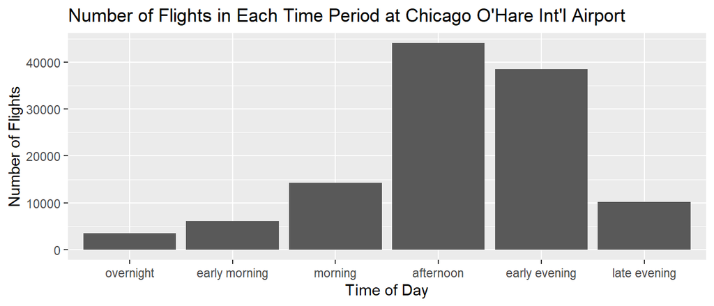

```r
ggplot(answer, aes(x=time_of_day,y=number_flights))+xlab("Time of Day")+ylab("Number of Flights")+ggtitle("Number of Flights in Each Time Period at Chicago O'Hare Int'l Airport")+geom_col()
```

5. Create a data summary table with the average daily number of passengers by month and year.
- Display this data summary with a bar chart where month is on the x-axis and average daily passenger counts are on the y axis
- Add meaningful axis labels and a title to this graph.
- Change the y axis scale labels so values are regular numbers with commas. *(Use `scale_y_continuous()` as below)*
- Display the graph with a different facet for each year

```r
## data summary
prob5 = ord %>%
  mutate(year=year(date),month=month(date,label=TRUE,locale="English")) %>%
  group_by(year,month,date) %>%
  summarize(daily_passengers=sum(all_total)) %>%
  group_by(month,year) %>%
  summarize(avg_daily_passengers=sum(daily_passengers/n())) %>%
  arrange(year) %>%
  relocate(month,.after=year)
prob5
```

```
## # A tibble: 60 × 3
## # Groups:   month [12]
##     year month avg_daily_passengers
##    <dbl> <ord>                <dbl>
##  1  2017 Jan                 13052.
##  2  2017 Feb                 10889.
##  3  2017 Mar                 13381.
##  4  2017 Apr                 15019.
##  5  2017 May                 14302.
##  6  2017 Jun                 16395.
##  7  2017 Jul                 17992.
##  8  2017 Aug                 17612.
##  9  2017 Sep                 14580.
## 10  2017 Oct                 12767.
## # … with 50 more rows
```

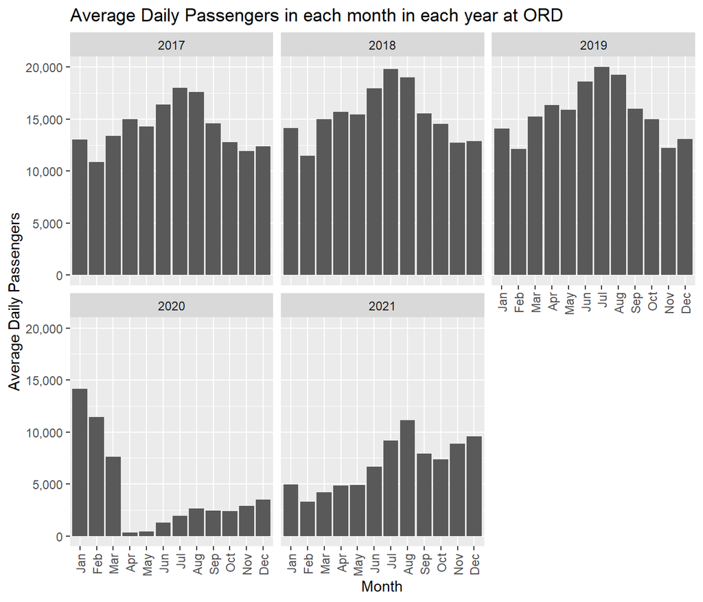

```r
## plot the table
ggplot(prob5, aes(x=month,y=avg_daily_passengers)) + geom_col()+xlab("Month")+ylab("Average Daily Passengers")+ggtitle("Average Daily Passengers in each month in each year at ORD")+
  scale_y_continuous(label = scales::comma)+facet_wrap(vars(year))+theme(axis.text.x = element_text(angle = 90, vjust = 0.5, hjust=1))
```

6. What striking feature is apparent in this graph? What explains this feature of the data?

> In 2020 and 2021, due to the outbreak of the pandemic, average daily number of passengers plummets.
7. Investigate the average number of passengers per day of the week for the years 2017–2019.
- For each day of the week (Sunday – Saturday), calculate the average number of arriving daily passengers to ORD on international flights. Display this table sorted from highest to lowest average. *(Hint: you need to total passengers by date and day of week before taking averages.)*
- Print the entire table

```r
ord %>%
  mutate(wday = wday(date,label=TRUE,locale="English"), year=year(date)) %>%
  filter(year=="2017"|year=="2018"|year=="2019") %>%
  group_by(date,wday) %>%
  summarize(passengers_date=sum(all_total)) %>%
  group_by(wday) %>%
  summarize(avg_passengers_wday=mean(passengers_date)) %>%
  arrange(desc(avg_passengers_wday))
```

```
## # A tibble: 7 × 2
##   wday  avg_passengers_wday
##   <ord>               <dbl>
## 1 Sat                17975.
## 2 Sun                16624.
## 3 Mon                15080.
## 4 Fri                15058.
## 5 Wed                13900.
## 6 Thu                13612.
## 7 Tue                13425.
```

8. Identify the 20 dates with the highest total number of arriving passengers. How many of these dates are the day of the week identified in the previous problem with the highest average?

```r
ord %>%
  group_by(date) %>%
  summarize(total_passengers=sum(all_total)) %>%
  arrange(desc(total_passengers)) %>%
  mutate(wday=wday(date)) %>%
  head(20) %>%
  filter(wday=="7") %>%
  nrow()
```

```
## [1] 19
```